# WeRateDogs Data Explanation

## by Emefiele-konyeri Awinrin

## Investigation Overview

In this investigation, i will be unveiling the most popular dog stage, the most common ratings, rating with the highest average favorite count and retweet count, correlation between favorite count and retweet count, the period of time with high engagements and the growth of interactions along the years.

## Dataset Overview

The WeRateDogs data consists of 2,174 tweets and 21 features('tweet_id', 'timestamp', 'source', 'text', 'rating_numerator', 'rating_denominator', 'name', 'stage', 'jpg_url', 'img_num', 'p1', 'p1_conf', 'p1_dog', 'p2', 'p2_conf', 'p2_dog', 'p3', 'p3_conf', 'p3_dog', 'retweet_count', 'favorite_count'), after data cleaning the dataset was transformed to 24 features(additional features: 'hour', 'month', 'date').

## Most popular dog stage

Most of the tweets in the dataset did not contain a dog stage, but for the tweets containing a dog stage pupper seems to be the most popular dog stage in the dataset followed by doggo

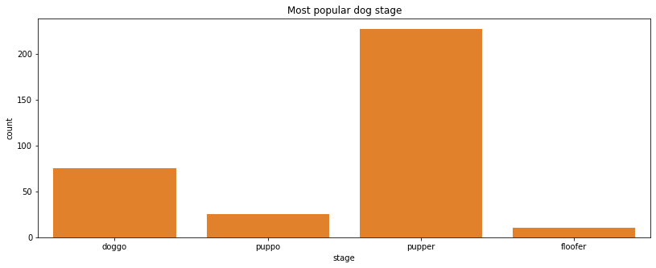

## Distribution Of Ratings

The Frequent occuring rating numerators are within the range of 7 to 15 with 12 the most frequent rating and 7 the least.

```
(0.0, 20.0)
```

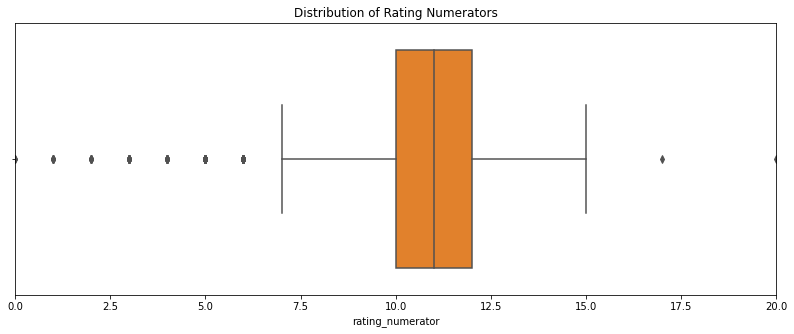

## Distribution Of Favorite Count

```
(0.0, 5000.0)
```

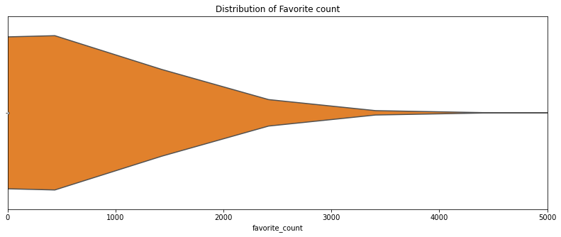

## Distribution Of Retweet Count

```
(0.0, 2000.0)
```

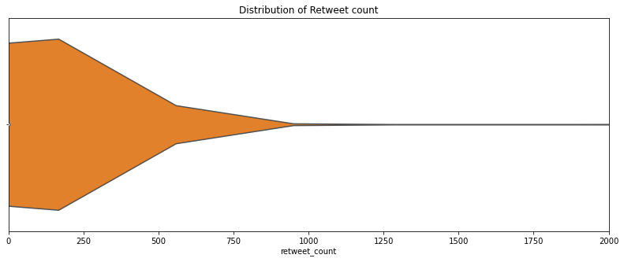

## Relationship between Rating number and Retweet count

rating 14 had the highest average retweet count followed by rating 13.

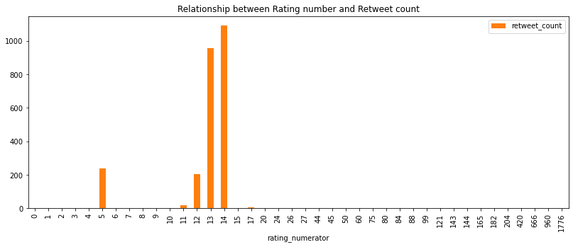

## Relationship between Rating number and Favorite count

rating 14 had the highest average favorite count followed by rating 13.

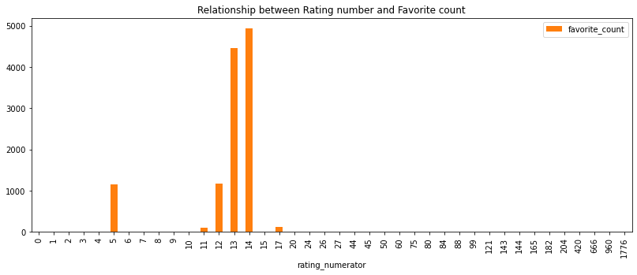

## Relationship between Retweet count and Favorite count

There is a positive correlation between favorite count and retweet count, which obviously mean if people favorite the tweet then there is a high tendency they would retweet it.

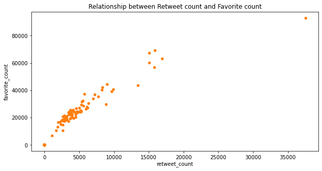

Engagements(favorite count and retweet count) are at a peak at 13.00PM and uninteractive hours from 4:00AM to 11:00AM

[figure not shown]

## Relationship between Month and number of Tweets

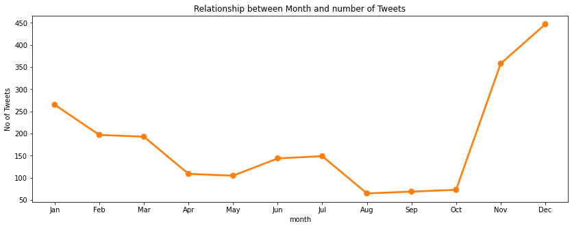

## Relationship between Year and number of Tweets

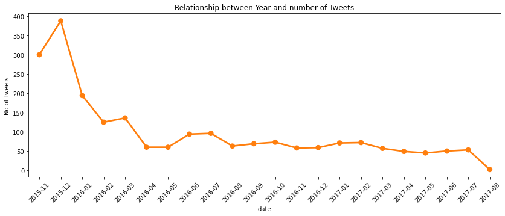

## Relationship between img_num, p1_conf, p2_conf and p3_conf

Image 4 has the highest average confident prediction for p1_conf,image 1 has the highest average confident prediction for p2_conf and p3_conf respectively.

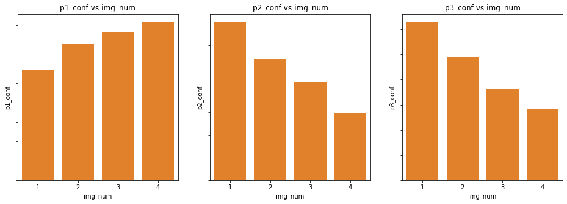

## Relationship between p1_conf, p2_conf, p3_conf

There is a negative correlation in first chart(p1_conf and p2_conf), negative correlation in second chart(p1_conf and p3_conf), postive correlation in third chart(p3_conf and p2_conf)

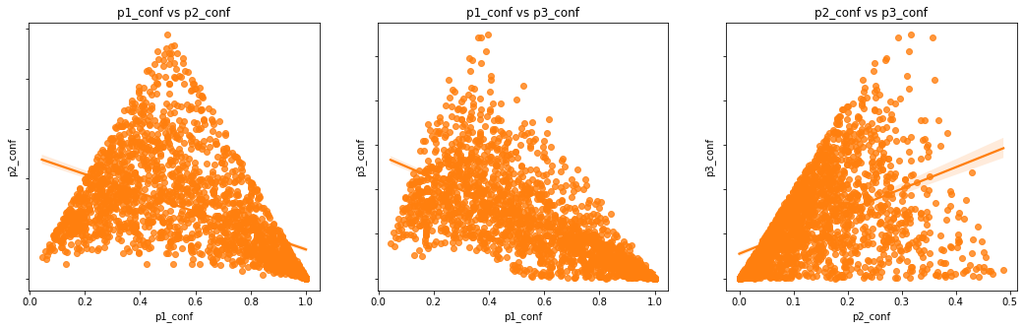